# Global Pollution Trends and Future Impact Analysis

Pankaj & Ankit

2026-04-06

# 1 Introduction

Pollution is one of the most critical global challenges affecting environmental sustainability and human health. This project analyzes global CO2 emission trends using R programming to understand historical patterns, identify key contributors, and evaluate potential future impacts.

# 2 Dataset

The dataset used in this project is sourced from Our World in Data. It contains country-wise information on CO2 emissions, population, and related environmental indicators across multiple years.

```r
# Load data
data <- read.csv("data.csv")

# View data
head(data)
```

```
##       country year iso_code population gdp cement_co2 cement_co2_per_capita co2
## 1 Afghanistan 1750      AFG    2802560  NA          0                     0  NA
## 2 Afghanistan 1751      AFG         NA  NA          0                    NA  NA
## 3 Afghanistan 1752      AFG         NA  NA          0                    NA  NA
## 4 Afghanistan 1753      AFG         NA  NA          0                    NA  NA
## 5 Afghanistan 1754      AFG         NA  NA          0                    NA  NA
## 6 Afghanistan 1755      AFG         NA  NA          0                    NA  NA
##   co2_growth_abs co2_growth_prct co2_including_luc co2_including_luc_growth_abs
## 1             NA              NA                NA                           NA
## 2             NA              NA                NA                           NA
## 3             NA              NA                NA                           NA
## 4             NA              NA                NA                           NA
## 5             NA              NA                NA                           NA
## 6             NA              NA                NA                           NA
##   co2_including_luc_growth_prct co2_including_luc_per_capita
```

[output cut: 160 more lines]

# 3 Libraries

The following libraries were used for data analysis and visualization:

```r
library(tidyverse)
```

```r
library(dplyr)
library(ggplot2)
library(readr)
library(corrplot)
library(caret)
library(plotly)
```

# 4 Data Cleaning

Before analysis, the dataset was cleaned to ensure accuracy and consistency.

```r
# Remove missing values
data <- data %>%
  filter(!is.na(co2), !is.na(population))

# Remove non-country data (like World, Asia)
data <- data %>%
  filter(nchar(iso_code) == 3)

# Remove zero or negative values
data <- data %>%
  filter(co2 > 0)

# Check structure
str(data)
```

```
## 'data.frame':    22386 obs. of  79 variables:
##  $ country                                  : chr  "Afghanistan" "Afghanistan" "Afghanistan" "Afghanistan" ...
##  $ year                                     : int  1949 1950 1951 1952 1953 1954 1955 1956 1957 1958 ...
##  $ iso_code                                 : chr  "AFG" "AFG" "AFG" "AFG" ...
##  $ population                               : num  7356890 7776180 7879343 7987784 8096703 ...
##  $ gdp                                      : num  NA 9.42e+09 9.69e+09 1.00e+10 1.06e+10 ...
##  $ cement_co2                               : num  0 0 0 0 0 0 0 0 0 0 ...
##  $ cement_co2_per_capita                    : num  0 0 0 0 0 0 0 0 0 0 ...
##  $ co2                                      : num  0.015 0.084 0.092 0.092 0.106 0.106 0.154 0.183 0.293 0.33 ...
##  $ co2_growth_abs                           : num  NA 0.07 0.007 0 0.015 0 0.048 0.029 0.11 0.037 ...
##  $ co2_growth_prct                          : num  NA 475 8.7 0 16 ...
##  $ co2_including_luc                        : num  6.12 7.17 8.09 9.01 10.07 ...
##  $ co2_including_luc_growth_abs             : num  NA 1.052 0.923 0.913 1.065 ...
##  $ co2_including_luc_growth_prct            : num  NA 17.2 12.9 11.3 11.8 ...
##  $ co2_including_luc_per_capita             : num  0.831 0.922 1.027 1.127 1.244 ...
```

[output cut: 65 more lines]

```r
#Check missing values
summary(is.na(data))
```

```
##   country           year          iso_code       population
##  Mode :logical   Mode :logical   Mode :logical   Mode :logical
##  FALSE:22386     FALSE:22386     FALSE:22386     FALSE:22386
##
##     gdp          cement_co2      cement_co2_per_capita    co2
##  Mode :logical   Mode :logical   Mode :logical         Mode :logical
##  FALSE:14548     FALSE:17391     FALSE:17391           FALSE:22386
##  TRUE :7838      TRUE :4995      TRUE :4995
##  co2_growth_abs  co2_growth_prct co2_including_luc co2_including_luc_growth_abs
##  Mode :logical   Mode :logical   Mode :logical     Mode :logical
##  FALSE:22109     FALSE:22091     FALSE:20588       FALSE:20334
##  TRUE :277       TRUE :295       TRUE :1798        TRUE :2052
##  co2_including_luc_growth_prct co2_including_luc_per_capita
##  Mode :logical                 Mode :logical
##  FALSE:20334                   FALSE:20588
##  TRUE :2052                    TRUE :1798
##  co2_including_luc_per_gdp co2_including_luc_per_unit_energy co2_per_capita
##  Mode :logical             Mode :logical                     Mode :logical
##  FALSE:14135               FALSE:9016                        FALSE:22386
##  TRUE :8251                TRUE :13370
##  co2_per_gdp     co2_per_unit_energy  coal_co2       coal_co2_per_capita
##  Mode :logical   Mode :logical       Mode :logical   Mode :logical
##  FALSE:14548     FALSE:9642          FALSE:17595     FALSE:17595
##  TRUE :7838      TRUE :12744         TRUE :4791      TRUE :4791
##  consumption_co2 consumption_co2_per_capita consumption_co2_per_gdp
##  Mode :logical   Mode :logical              Mode :logical
##  FALSE:4063      FALSE:4063                 FALSE:3908
##  TRUE :18323     TRUE :18323                TRUE :18478
##  cumulative_cement_co2 cumulative_co2  cumulative_co2_including_luc
##  Mode :logical         Mode :logical   Mode :logical
##  FALSE:17391           FALSE:22386     FALSE:20588
##  TRUE :4995                            TRUE :1798
##  cumulative_coal_co2 cumulative_flaring_co2 cumulative_gas_co2
##  Mode :logical       Mode :logical          Mode :logical
##  FALSE:17595         FALSE:11869            FALSE:14044
##  TRUE :4791          TRUE :10517            TRUE :8342
##  cumulative_luc_co2 cumulative_oil_co2 cumulative_other_co2 energy_per_capita
##  Mode :logical      Mode :logical      Mode :logical        Mode :logical
##  FALSE:20588        FALSE:21278        FALSE:1734           FALSE:9695
##  TRUE :1798         TRUE :1108         TRUE :20652          TRUE :12691
```

[output cut: 53 more lines]

```
##  Mode :logical          Mode :logical
##  FALSE:1610             FALSE:21863
##  TRUE :20776            TRUE :523
##  temperature_change_from_ch4 temperature_change_from_co2
##  Mode :logical               Mode :logical
##  FALSE:21060                 FALSE:21863
##  TRUE :1326                  TRUE :523
##  temperature_change_from_ghg temperature_change_from_n2o total_ghg
##  Mode :logical               Mode :logical               Mode :logical
##  FALSE:21863                 FALSE:21060                 FALSE:21019
##  TRUE :523                   TRUE :1326                  TRUE :1367
##  total_ghg_excluding_lucf trade_co2       trade_co2_share
##  Mode :logical            Mode :logical   Mode :logical
##  FALSE:20889              FALSE:4063      FALSE:4063
##  TRUE :1497               TRUE :18323     TRUE :18323
```

# 5 Analysis

## 5.1 Which countries emit the most CO2 globally?

```r
top_countries <- data %>%
  group_by(country) %>%
  summarise(total_co2 = sum(co2, na.rm=TRUE)) %>%
  arrange(desc(total_co2)) %>%
  head(10)

top_countries
```

```
## # A tibble: 10 × 2
##    country        total_co2
##    <chr>              <dbl>
##  1 United States    434867.
##  2 China            285087.
##  3 Russia           122808.
##  4 Germany           95132.
##  5 United Kingdom    79394.
##  6 Japan             69612.
##  7 India             66073.
##  8 France            40048.
##  9 Canada            35644.
## 10 Ukraine           31236.
```

**Inference:** Top countries contributing to CO2 emissions are shown above.

## 5.2 How has global CO2 emission changed over time?

```r
theme_set(theme_minimal())

global_trend <- data %>%
  group_by(year) %>%
  summarise(total_co2 = sum(co2, na.rm=TRUE))

trend <- ggplot(global_trend, aes(x=year, y=total_co2)) +
  geom_line(color="blue") +
  labs(title="Global CO2 Emissions Over Time",
       x="Year",
       y="Total CO2 Emissions")
plotly::ggplotly(trend)
```

[interactive chart not shown]

**Inference:** Global CO2 emissions have shown a continuous increasing trend over time, indicating rising pollution levels.

## 5.3 Which year recorded the highest global CO2 emissions?

```r
peak_year <- global_trend[which.max(global_trend$total_co2), ]

peak_year
```

```
## # A tibble: 1 × 2
##    year total_co2
##   <int>     <dbl>
## 1  2024    37398.
```

**Inference:** The year shown above recorded the highest global CO2 emissions, indicating peak pollution levels.

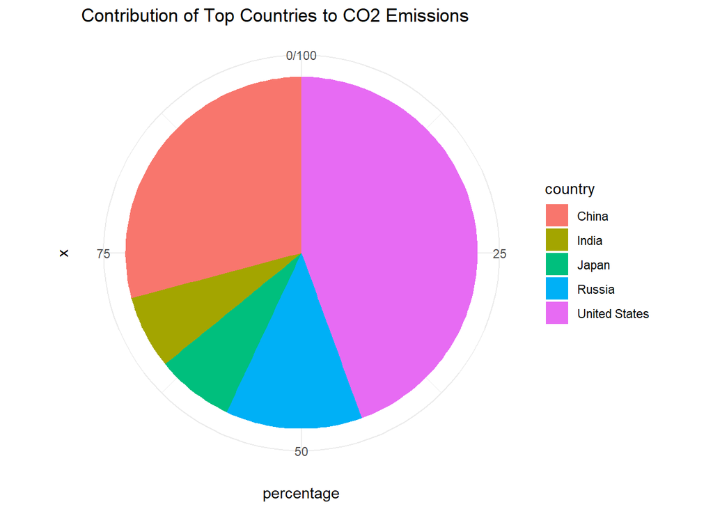

```r
top5 <- c("United States", "China", "India", "Russia", "Japan")

share_data <- data %>%
  filter(country %in% top5) %>%
  group_by(country) %>%
  summarise(total_co2 = sum(co2, na.rm=TRUE))

share_data$percentage <- (share_data$total_co2 / sum(share_data$total_co2)) * 100

ggplot(share_data, aes(x="", y=percentage, fill=country)) +
  geom_bar(stat="identity", width=1) +
  coord_polar("y") +
  labs(title="Contribution of Top Countries to CO2 Emissions")
```

## 5.5 How do CO2 emissions per person vary across countries?

```r
data$co2_per_capita <- data$co2 / data$population

top_per_capita <- data %>%
  filter(!is.na(co2_per_capita)) %>%
  filter(nchar(iso_code) == 3) %>%
  group_by(country) %>%
  summarise(avg_per_capita = mean(co2_per_capita, na.rm=TRUE)) %>%
  arrange(desc(avg_per_capita)) %>%
  head(10)

top_per_capita
```

```
## # A tibble: 10 × 2
##    country                   avg_per_capita
##    <chr>                              <dbl>
##  1 Sint Maarten (Dutch part)      0.000143
##  2 Curacao                        0.0000491
##  3 Qatar                          0.0000461
##  4 Kuwait                         0.0000289
##  5 United Arab Emirates           0.0000287
##  6 Luxembourg                     0.0000252
##  7 Brunei                         0.0000243
##  8 Bahrain                        0.0000200
##  9 Saudi Arabia                   0.0000141
## 10 Trinidad and Tobago            0.0000134
```

**Inference:** The results show that some countries have significantly higher emissions per person, indicating greater individual environmental impact.

## 5.6 What is the distribution of CO2 emissions across countries?

```r
distribution <- ggplot(data, aes(x=co2)) +
  geom_histogram(bins=30, fill="steelblue", color="black") +
  labs(
    title="Distribution of CO2 Emissions",
    x="CO2 Emissions",
    y="Frequency"
  )
plotly::ggplotly(distribution)
```

[interactive chart not shown]

**Inference:** The distribution indicates that most countries have relatively low emissions, while a few countries contribute disproportionately high emissions.

## 5.7 Are there any extreme outliers in CO2 emissions?

```r
box <- ggplot(data, aes(y = co2)) +
  geom_boxplot(fill = "orange", color = "black") +
  scale_y_log10() +
  labs(
    title = "Boxplot of CO2 Emissions (Log Scale)",
    y = "CO2 Emissions (log scale)"
  ) +
  theme_minimal() +
  theme(
    axis.text.x = element_blank(),
    axis.ticks.x = element_blank()
  )
plotly::ggplotly(box)
```

[interactive chart not shown]

**Inference:** The boxplot clearly highlights extreme outliers, representing countries with exceptionally high emission levels compared to others.

## 5.8 Is global CO2 emission increasing over time?

```r
trend_model <- lm(total_co2 ~ year, data = global_trend)

summary(trend_model)
```

```
##
## Call:
## lm(formula = total_co2 ~ year, data = global_trend)
##
## Residuals:
##     Min      1Q  Median      3Q     Max
## -8389.7 -4867.4  -576.2  3764.2 14137.4
##
## Coefficients:
##               Estimate Std. Error t value Pr(>|t|)
## (Intercept) -2.480e+05  1.082e+04  -22.92   <2e-16 ***
## year         1.340e+02  5.665e+00   23.66   <2e-16 ***
## ---
## Signif. codes:  0 '***' 0.001 '**' 0.01 '*' 0.05 '.' 0.1 ' ' 1
##
## Residual standard error: 5802 on 228 degrees of freedom
## Multiple R-squared:  0.7106, Adjusted R-squared:  0.7093
## F-statistic: 559.8 on 1 and 228 DF,  p-value: < 2.2e-16
```

**Inference:** The positive trend indicates that global CO2 emissions are increasing over time, highlighting worsening pollution levels.

## 5.9 What could be the future trend of CO2 emissions if current patterns continue?

```r
global_trend$future_co2 <- global_trend$total_co2 * 1.1

pred1 <- ggplot(global_trend, aes(x=year)) +
  geom_line(aes(y=total_co2), color="blue") +
  geom_line(aes(y=future_co2), color="red") +
  labs(
    title="Actual vs Predicted CO2 Emissions Over Time",
    x="Year",
    y="CO2 Emissions"
  )
plotly::ggplotly(pred1)
```

[interactive chart not shown]

**Inference:** The visualization indicates a strong upward trend in global CO2 emissions over time. The predicted values closely follow historical patterns, suggesting that emissions may continue increasing if current trends persist.

## 5.10 Which countries should take immediate action based on high emissions?

```r
high_risk <- data %>%
  filter(nchar(iso_code) == 3) %>%
  group_by(country) %>%
  summarise(total_co2 = sum(co2, na.rm=TRUE)) %>%
  arrange(desc(total_co2)) %>%
  head(5)

high_risk
```

```
## # A tibble: 5 × 2
##   country        total_co2
##   <chr>              <dbl>
## 1 United States    434867.
## 2 China            285087.
## 3 Russia           122808.
## 4 Germany           95132.
## 5 United Kingdom    79394.
```

**Inference:** Countries with the highest emissions should take immediate action to control pollution and reduce environmental impact.

## 5.11 How might increasing CO2 emissions impact future environmental conditions?

```r
model <- lm(co2 ~ year, data = data)

summary(model)
```

```
##
## Call:
## lm(formula = co2 ~ year, data = data)
##
## Residuals:
##     Min      1Q  Median      3Q     Max
##  -139.8   -98.7   -67.7   -15.8 12149.2
##
## Coefficients:
##               Estimate Std. Error t value Pr(>|t|)
## (Intercept) -1.759e+03  1.231e+02  -14.30   <2e-16 ***
## year         9.383e-01  6.274e-02   14.95   <2e-16 ***
## ---
## Signif. codes:  0 '***' 0.001 '**' 0.01 '*' 0.05 '.' 0.1 ' ' 1
##
## Residual standard error: 444.9 on 22384 degrees of freedom
## Multiple R-squared:  0.009892,   Adjusted R-squared:  0.009848
## F-statistic: 223.6 on 1 and 22384 DF,  p-value: < 2.2e-16
```

**Inference:** The model shows a positive relationship between year and CO2 emissions, indicating that pollution is increasing over time and may worsen future environmental conditions.

## 5.12 How can future CO2 emissions be visualized based on current trends?

```r
visual <- ggplot(global_trend, aes(x=year)) +
  geom_line(aes(y=total_co2), color="blue") +
  geom_smooth(aes(y=total_co2), method="lm", color="red") +
  labs(
    title="Trend Projection of CO2 Emissions",
    x="Year",
    y="CO2 Emissions"
  )
plotly::ggplotly(visual)
```

[interactive chart not shown]

**Inference:** The trend line indicates that CO2 emissions are expected to continue rising if current patterns persist.

## 5.13 Which countries show the fastest growth in CO2 emissions?

```r
growth_data <- data %>%
  filter(nchar(iso_code) == 3) %>%
  group_by(country) %>%
  summarise(growth = max(co2, na.rm=TRUE) - min(co2, na.rm=TRUE)) %>%
  arrange(desc(growth)) %>%
  head(10)

growth_data
```

```
## # A tibble: 10 × 2
##    country       growth
##    <chr>          <dbl>
##  1 China         12272.
##  2 United States  6127.
##  3 India          3193.
##  4 Russia         2536.
##  5 Japan          1312.
##  6 Germany        1117.
##  7 Indonesia       812.
##  8 Iran            793.
##  9 Ukraine         744.
## 10 Saudi Arabia    708.
```

**Inference:** These countries have shown the highest increase in emissions over time, indicating rapid industrial or economic growth.

## 5.14 Which countries are the top polluters in recent years?

```r
latest_year <- max(data$year, na.rm=TRUE)

recent_data <- data %>%
  filter(year == latest_year) %>%
  filter(nchar(iso_code) == 3) %>%
  arrange(desc(co2)) %>%
  head(10)

recent_data[, c("country", "co2")]
```

```
##          country       co2
## 1          China 12289.037
## 2  United States  4904.120
## 3          India  3193.478
## 4         Russia  1780.524
## 5          Japan   961.867
## 6      Indonesia   812.220
## 7           Iran   792.631
## 8   Saudi Arabia   692.133
## 9    South Korea   583.679
## 10       Germany   572.319
```

**Inference:** The most recent data highlights current global pollution leaders, which are key contributors to environmental issues today.

## 5.15 How do CO2 emissions of top countries change over time?

```r
top5 <- c("United States", "China", "India", "Russia", "Japan")

trend_data <- data %>%
  filter(country %in% top5)

top <- ggplot(trend_data, aes(x=year, y=co2, color=country)) +
  geom_line(size=1) +
  labs(
    title="CO2 Emission Trends of Top 5 Countries",
    x="Year",
    y="CO2 Emissions"
  )
plotly::ggplotly(top)
```

[interactive chart not shown]

*Inference:* The graph shows how emissions have evolved over time for major countries, highlighting differences in growth patterns and industrial development.

## 5.16 What is the percentage contribution of top countries to total emissions?

```r
total_global <- sum(data$co2, na.rm=TRUE)

top5_data <- data %>%
  filter(country %in% c("United States", "China", "India", "Russia", "Japan")) %>%
  group_by(country) %>%
  summarise(total = sum(co2, na.rm=TRUE))

top5_data$percentage <- (top5_data$total / total_global) * 100

top5_data
```

```
## # A tibble: 5 × 3
##   country         total percentage
##   <chr>           <dbl>      <dbl>
## 1 China         285087.      15.8
## 2 India          66073.       3.67
## 3 Japan          69612.       3.86
## 4 Russia        122808.       6.81
## 5 United States 434867.      24.1
```

**Inference:** A small number of countries contribute a large percentage of global emissions.

## 5.17 Are CO2 emissions increasing at an accelerating rate?

```r
global_trend$change <- c(NA, diff(global_trend$total_co2))

acc <- ggplot(global_trend, aes(x=year, y=change)) +
  geom_line(color="purple") +
  labs(
    title="Yearly Change in CO2 Emissions",
    x="Year",
    y="Change in Emissions"
  )
plotly::ggplotly(acc)
```

[interactive chart not shown]

**Inference:** The increasing fluctuations suggest that emissions are not just rising but may be accelerating.

## 5.18 Which countries have reduced their CO2 emissions over time?

```r
reduction <- data %>%
  filter(nchar(iso_code) == 3) %>%
  group_by(country) %>%
  summarise(change = last(co2) - first(co2)) %>%
  arrange(change)

head(reduction, 10)
```

```
## # A tibble: 10 × 2
##    country                    change
##    <chr>                       <dbl>
##  1 Curacao                   -3.84
##  2 Niue                       0.004
##  3 Saint Helena               0.007
##  4 Tuvalu                     0.007
##  5 Wallis and Futuna          0.013
##  6 Micronesia (country)       0.0150
##  7 Andorra                    0.0220
##  8 Montserrat                 0.023
##  9 Nauru                      0.032
## 10 Sint Maarten (Dutch part)  0.0350
```

## 5.19 Which countries are at highest risk if current trends continue?

```r
risk_data <- growth_data %>%
  head(5)

risk_data
```

```
## # A tibble: 5 × 2
##   country       growth
##   <chr>          <dbl>
## 1 China         12272.
## 2 United States  6127.
## 3 India          3193.
## 4 Russia         2536.
## 5 Japan          1312.
```

**Inference:** Countries with rapid emission growth are at higher environmental risk in the future.

## 5.20 How does CO2 emission vary across different time periods?

```r
data$period <- ifelse(data$year < 1980, "Before 1980",
                ifelse(data$year < 2000, "1980-2000", "After 2000"))

period_data <- data %>%
  group_by(period) %>%
  summarise(avg_co2 = mean(co2, na.rm=TRUE))

period_data
```

```
## # A tibble: 3 × 2
##   period      avg_co2
##   <chr>         <dbl>
## 1 1980-2000     103.
## 2 After 2000    151.
## 3 Before 1980    44.3
```

**Inference:** CO2 emissions have increased significantly in recent decades, especially after 2000, indicating rapid industrial growth and environmental impact.

## 5.21 How does population size influence total CO2 emissions?

```r
effect <- ggplot(data, aes(x=population, y=co2)) +
  geom_point(alpha=0.5, color="blue") +
  labs(
    title="Population vs CO2 Emissions",
    x="Population",
    y="CO2 Emissions"
  )
plotly::ggplotly(effect)
```

[interactive chart not shown]

**Inference:** Countries with larger populations tend to have higher total emissions.

## 5.22 How do total emissions differ from per capita emissions?

```r
compare <- ggplot(data, aes(x=co2_per_capita, y=co2)) +
  geom_point(alpha=0.5, color="red") +
  labs(
    title="Per Capita vs Total Emissions",
    x="CO2 per Capita",
    y="Total CO2"
  )
plotly::ggplotly(compare)
```

[interactive chart not shown]

**Inference:** Some countries have high total emissions but lower per capita values.

## 5.23 Which countries have the highest per capita emissions in recent years?

```r
latest_year <- max(data$year, na.rm=TRUE)

recent_pc <- data %>%
  filter(year == latest_year) %>%
  filter(nchar(iso_code) == 3) %>%
  arrange(desc(co2_per_capita)) %>%
  head(10)

recent_pc[, c("country","co2_per_capita")]
```

```
##                      country co2_per_capita
## 1                      Qatar   4.127109e-05
## 2                     Kuwait   2.624760e-05
## 3                     Brunei   2.604520e-05
## 4                    Bahrain   2.426980e-05
## 5        Trinidad and Tobago   2.293176e-05
## 6               Saudi Arabia   2.037918e-05
## 7       United Arab Emirates   2.013107e-05
## 8              New Caledonia   1.806564e-05
## 9  Sint Maarten (Dutch part)   1.655446e-05
## 10                      Oman   1.565111e-05
```

**Inference:** Some smaller countries have extremely high emissions per person.

## 5.24 What is the smoothed trend of global CO2 emissions?

```r
smooth <- ggplot(global_trend, aes(x=year, y=total_co2)) +
  geom_line(color="gray") +
  geom_smooth(method="loess", color="red") +
  labs(title="Smoothed CO2 Emission Trend")
plotly::ggplotly(smooth)
```

[interactive chart not shown]

**Inference:** The smoothed curve highlights the long-term upward trend in emissions.

## 5.25 How are CO2 emissions distributed across countries?

```r
den <- ggplot(data, aes(x=co2)) +
  geom_density(fill="green", alpha=0.5)
plotly::ggplotly(den)
```

[interactive chart not shown]

**Inference:** Most countries cluster at lower emission levels with a long tail of high emitters.

## 5.26 How have emissions changed in the last decade?

```r
recent_data <- data %>%
  filter(year >= max(year) - 10)

dec <- ggplot(recent_data, aes(x=year, y=co2)) +
  geom_line(color="blue")
plotly::ggplotly(dec)
```

[interactive chart not shown]

**Inference:** Recent years show continued increase in emissions.

## 5.27 Which countries have stable emission patterns over time?

```r
stability <- data %>%
  filter(nchar(iso_code) == 3) %>%
  group_by(country) %>%
  summarise(sd_co2 = sd(co2, na.rm=TRUE)) %>%
  arrange(sd_co2)

head(stability, 10)
```

```
## # A tibble: 10 × 2
##    country                    sd_co2
##    <chr>                       <dbl>
##  1 Niue                      0.00152
##  2 Tuvalu                    0.00274
##  3 Saint Helena              0.00296
##  4 Wallis and Futuna         0.00315
##  5 Montserrat                0.0128
##  6 Saint Pierre and Miquelon 0.0175
##  7 Kiribati                  0.0181
##  8 Cook Islands              0.0236
##  9 Micronesia (country)      0.0241
## 10 Marshall Islands          0.0243
```

**Inference:** Countries with low variation show stable emission patterns.

## 5.28 Is there a correlation between population and CO2 emissions?

```r
cor(data$population, data$co2, use="complete.obs")
```

```
## [1] 0.6311937
```

**Inference:** There is a positive correlation between population and emissions.

## 5.29 How does log transformation help in understanding emissions?

```r
log1 <- ggplot(data, aes(x=log(co2))) +
  geom_histogram(bins=30, fill="purple")
plotly::ggplotly(log1)
```

[interactive chart not shown]

**Inference:** Log transformation reduces skewness and improves visualization.

## 5.30 How have top contributors changed over time?

```r
top_countries_names <- top_countries$country

trend_top <- data %>%
  filter(country %in% top_countries_names)

trend2 <- ggplot(trend_top, aes(x=year, y=co2, color=country)) +
  geom_line()
plotly::ggplotly(trend2)
```

[interactive chart not shown]

## 5.31 What share do top countries contribute globally?

```r
top_total <- sum(top_countries$total_co2)
global_total <- sum(data$co2, na.rm=TRUE)

top_total / global_total * 100
```

```
## [1] 69.91129
```

**Inference:** Top countries contribute a major portion of global emissions.

## 5.32 Which countries have the lowest emissions?

```r
low_emitters <- data %>%
  filter(nchar(iso_code) == 3) %>%
  arrange(co2) %>%
  head(10)

low_emitters[, c("country","co2")]
```

```
##      country   co2
## 1    Armenia 0.001
## 2    Armenia 0.001
## 3    Armenia 0.001
## 4    Armenia 0.001
## 5  Australia 0.001
## 6  Australia 0.001
## 7  Australia 0.001
## 8  Australia 0.001
## 9  Australia 0.001
## 10 Australia 0.001
```

## 5.33 How variable are emissions globally?

```r
var(data$co2, na.rm=TRUE)
```

```
## [1] 199870.7
```

**Inference:** High variance indicates unequal emission distribution.

## 5.34 How does emission growth indicate future risk?

```r
risk <- ggplot(growth_data, aes(x=reorder(country, growth), y=growth)) +
  geom_bar(stat="identity", fill="red") +
  coord_flip()
plotly::ggplotly(risk)
```

[interactive chart not shown]

**Inference:** Countries with highest growth pose future environmental risks.

## 5.35 What overall patterns can be observed in global pollution trends?

```r
summary(global_trend$total_co2)
```

```
##      Min.   1st Qu.    Median      Mean   3rd Qu.      Max.
##     9.306   210.004  2973.988  7835.396 11777.002 37398.067
```

**Inference:** Global emissions show a clear increasing pattern with significant disparities across countries.

## 5.36 What are the descriptive statistics of CO2 emissions?

```r
mean(data$co2, na.rm=TRUE)
```

```
## [1] 80.50304
```

```r
median(data$co2, na.rm=TRUE)
```

```
## [1] 3.2115
```

```r
sd(data$co2, na.rm=TRUE)
```

```
## [1] 447.069
```

```r
quantile(data$co2, probs = c(0.25, 0.5, 0.75), na.rm=TRUE)
```

```
##      25%      50%      75%
##  0.37700  3.21150 25.31125
```

**Inference:** CO2 emissions show high variability with a significant difference between median and maximum values, indicating skewness.

## 5.37 What is the standard deviation of CO2 emissions?

```r
sd(data$co2, na.rm=TRUE)
```

```
## [1] 447.069
```

**Inference:** High standard deviation indicates unequal emission distribution across countries.

## 5.38 What is the distribution shape of CO2 emissions?

```r
distribution1 <- ggplot(data, aes(x=co2)) +
  geom_histogram(bins=30, fill="blue") +
  geom_density(color="red")
plotly::ggplotly(distribution1)
```

[interactive chart not shown]

*Inference:* The distribution is right-skewed, meaning most countries have low emissions while few have very high emissions.

## 5.39 Are there outliers in CO2 emissions using IQR method?

```r
Q1 <- quantile(data$co2, 0.25, na.rm=TRUE)
Q3 <- quantile(data$co2, 0.75, na.rm=TRUE)
IQR_val <- Q3 - Q1

lower <- Q1 - 1.5 * IQR_val
upper <- Q3 + 1.5 * IQR_val

outliers <- data %>%
  filter(co2 < lower | co2 > upper)

outliers %>%
  select(country, co2) %>%
  distinct(country, .keep_all = TRUE)
```

```
##                 country     co2
## 1               Algeria  66.124
## 2             Argentina  63.073
## 3             Australia  63.003
## 4               Austria  65.790
## 5            Bangladesh  64.763
## 6               Belarus  65.814
## 7               Belgium  64.776
## 8                Brazil  64.154
## 9              Bulgaria  66.308
## 10               Canada  67.271
## 11                Chile  64.048
## 12                China  72.646
## 13             Colombia  63.260
## 14              Czechia  69.152
```

[output cut: 49 more lines]

*Inference:* Outliers represent countries with extremely high emissions.

## 5.40 What is the correlation between population and CO2 emissions?

```r
cor(data$population, data$co2, use="complete.obs")
```

```
## [1] 0.6311937
```

*Inference:* A positive correlation suggests that higher population is associated with higher emissions.

## 5.41 How can correlation between variables be visualized?

```r
corr1 <- ggplot(data, aes(x=population, y=co2)) +
  geom_point(alpha=0.5) +
  geom_smooth(method="lm", color="red")
plotly::ggplotly(corr1)
```

[interactive chart not shown]

*Inference:* The plot shows a positive relationship between population and emissions.

## 5.42 How strong is the relationship between variables?

```r
correlation <- cor(data$population, data$co2, use="complete.obs")

correlation
```

```
## [1] 0.6311937
```

*Inference:* The strength of correlation indicates how strongly population influences emissions.

## 5.43 Can we model CO2 emissions using population?

```r
model <- lm(co2 ~ population, data = data)

summary(model)
```

```
##
## Call:
## lm(formula = co2 ~ population, data = data)
##
## Residuals:
##     Min      1Q  Median      3Q     Max
## -2433.1   -25.3   -12.7    -8.7  7841.7
##
## Coefficients:
##              Estimate Std. Error t value Pr(>|t|)
## (Intercept) 9.669e+00  2.390e+00   4.046 5.22e-05 ***
## population  3.127e-06  2.568e-08 121.753  < 2e-16 ***
## ---
## Signif. codes:  0 '***' 0.001 '**' 0.01 '*' 0.05 '.' 0.1 ' ' 1
##
## Residual standard error: 346.8 on 22384 degrees of freedom
## Multiple R-squared:  0.3984, Adjusted R-squared:  0.3984
## F-statistic: 1.482e+04 on 1 and 22384 DF,  p-value: < 2.2e-16
```

*Inference:* The regression model shows how population influences CO2 emissions.

## 5.44 What do regression coefficients indicate?

```r
coef(model)
```

```
##  (Intercept)   population
## 9.668677e+00 3.126621e-06
```

*Inference:* Coefficients represent how much CO2 emissions change with population.

## 5.45 Can we predict CO2 emissions on unseen data using regression?

```r
# Split data
set.seed(123)
train_index <- createDataPartition(data$co2, p = 0.7, list = FALSE)

train_data <- data[train_index, ]
test_data  <- data[-train_index, ]

# Train model
model <- lm(co2 ~ year, data = train_data)

# Predict on unseen data
prediction <- predict(model, newdata = test_data)

# View predictions
head(data.frame(
  Actual = test_data$co2,
  Predicted = prediction
))
```

```
##    Actual Predicted
## 3   0.092  70.26912
## 4   0.092  71.23942
## 6   0.106  73.18001
## 8   0.183  75.12061
## 16  0.839  82.88300
## 29  2.384  95.49689
```

*Inference:* The model was trained on 70% of the data and used to predict CO2 emissions on unseen test data. The predicted values provide an estimate based on the year variable.

## 5.46 How can we visually evaluate the model performance?

```r
library(ggplot2)

# Create result dataframe
results <- data.frame(
  Actual = test_data$co2,
  Predicted = prediction
)

# Plot
visual1 <- ggplot(results, aes(x = Actual, y = Predicted)) +
  geom_point(color = "blue", alpha = 0.5) +
  geom_abline(slope = 1, intercept = 0, color = "red") +
  labs(
    title = "Actual vs Predicted CO2 Emissions",
    x = "Actual CO2",
    y = "Predicted CO2"
  )+
  coord_flip()
plotly::ggplotly(visual1)
```

[interactive chart not shown]

*Inference:* The visualization shows that the model captures the overall trend but does not accurately predict all CO2 values. The wide spread of points indicates prediction errors and suggests that additional variables may be needed for better performance.

# 6 Key Insights

- After data cleaning and preprocessing, the dataset provided reliable country-level CO2 emission analysis.
- Global CO2 emissions show a strong increasing trend over time, supported by both visualization and regression modeling.
- A small number of countries contribute a disproportionately large share of total emissions, highlighting global imbalance.
- Per capita analysis reveals that some countries with smaller populations still have high individual emission levels.
- The distribution of CO2 emissions is highly skewed, with several extreme outliers identified using boxplots and IQR methods.
- Correlation analysis indicates a positive relationship between population and CO2 emissions, though with variability.
- Regression modeling suggests that if current trends continue, CO2 emissions are likely to increase further, indicating future environmental risk.

# 7 Conclusion

This project analyzed global CO2 emission trends using R, incorporating data cleaning, exploratory data analysis, visualization, correlation, and regression techniques. The findings reveal a consistent rise in emissions over time, with significant disparities among countries.

Advanced analysis techniques such as boxplots, correlation, and regression provided deeper insights into emission patterns and relationships between variables. The results highlight that while population contributes to emissions, other factors also influence variability across countries.

Overall, the study emphasizes the urgent need for effective environmental policies and sustainable practices. If current trends continue, future environmental conditions may worsen, making it essential to take immediate global action to reduce pollution.